# QA Session / PCA

## The Curse of Dimensionality (Richard Bellman):

1. In machine learning world, it refers to the scenario when the number of dimensionality (features, input variables, factors) increases, the performance of our algorithm will deteriorate, especially for those algorithms which couldn’t scale well (such as KNN, clustering algorithms rely on distance calculations)
2. Mathematically speaking, the problem is that when the dimensionality increases, the volume of the space increases so fast that the available data become sparse. [quote from Wikipedia](https://en.wikipedia.org/wiki/Curse_of_dimensionality)
3. Graphical explaination
   - Finding treasure in the high dimension space ( with D dimensions each dimension has M states, we will have $M^D$ possible combinations. This number exponentially grows)

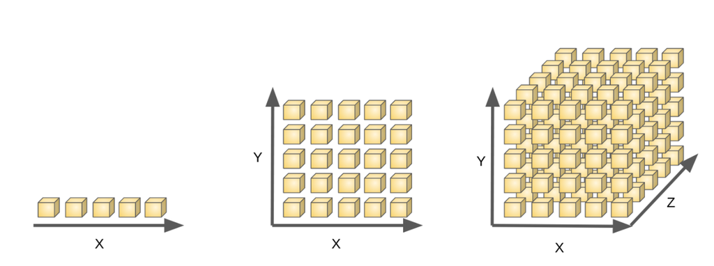

   - Hypercube
     - A hypercube is a generalization of a cube to an arbitrary number of dimensions. When p = 1, a hypercube is simply a line segment, when p = 2 it is a square, and when p = 100 it is a 100-dimensional cube. - from ISLR Sixth p182

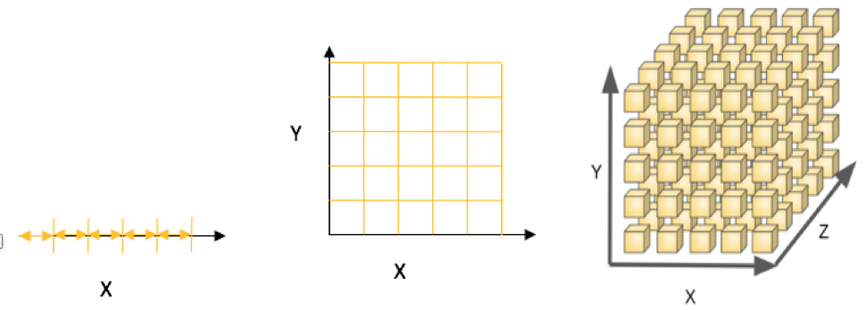

     - sampling density is the number of samples per unit distance. sampling density is proportional to $(Num of Observations)^\frac{1}{D}$
     - Now suppose that we wish to make a prediction for a test observation by creating a p-dimensional hypercube centered around the test observation that contains, on average, 10 % of the training observations. Features along each dimension is uniformly (evenly) distributed on [0, 1]. For p = 1,2, and 100, what is the length of each side of the hypercube? - from ISLR Sixth p182
       - p = 1, L = $\frac{1}{10}$ = 0.1
       - p = 2, L = $(\frac{1}{10})^\frac{1}{2}$ = 0.32
       - p = 100, L = $(\frac{1}{10})^\frac{1}{100}$ = 0.98

## Approaches to tackle the curse of dimensionality

1. Increasing the number of observations
2. Reducing the number of dimensions ( more pragmatic solution)
- Feature Selection - select a subset of the original set of features
  - i.e. Regularized Regression has the built-in feature selection
- Feature Extraction - create a new, smaller set of features out of the original set
  - PCA (Principlal Component Analysis)
  - LDA (Linear Discriminant Analysis)

## PCA (Principal Component Analysis)

1. General fundamentals:
- Unsupervised Algorithm
- New set of features are the linear combination of the original features
- New features are orthogonal ( meaning that they are uncorrelated)
- The rank of the PCs are according to their “explained variance” (The first principal component (PC1) explains the most variance in your dataset; PC2 explains the second most variance, and so on…)
- Dimensionality is reduced by limiting the number of PCs to keep based on cumulative explained variance
- Normalize the dataset, before applying PCA
2. Visual summary ([borrowed from this site](https://medium.freecodecamp.org/the-curse-of-dimensionality-how-we-can-save-big-data-from-itself-d9fa0f872335)):

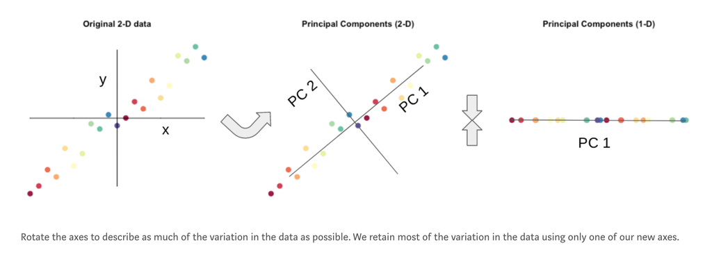

3. Deeper view ( mathematical view )
- Singular Value Decomposition (SVD)
  - [Here is a good starting point from Wikipedia](https://en.wikipedia.org/wiki/Singular_value_decomposition)

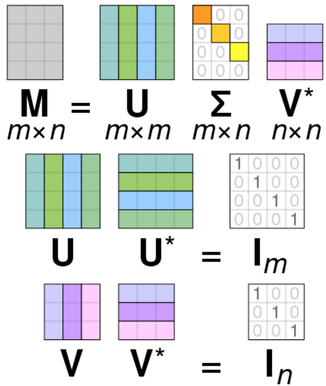

  - U is mxm square matrix - Unitary matrix
  - V is nxn sqaure matrix - Unitary matrix
  - $\sum$ is diagonal matrix

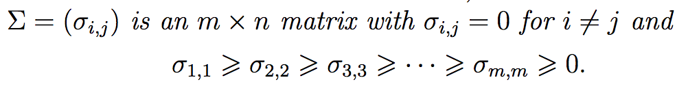

  - Exists for all X matrices
- Eigen Decomposition
  - put together the set of eigenvectors of A in a matrix denoted U. Each column of U is an eigenvector of A. The eigenvalues are stored in a diagonal matrix (denoted Λ), where the diagonal elements gives the eigenvalues (and all the other values are zeros)

  > $AU = U\Lambda$  
  > $A = U{\Lambda}U^{-1}$
  - Not all matrices have Eigen decomposition
  - Postitive semi definite matrices always have Eigen decompostion. A matrix is said to be positive semi-definite when it can be obtained as the product of a matrix by its transpose. Thus, they are symmetric.
  - The important properties of a positive semi-definite matrix is that its eigenvalues are always positive or null, and that its eigenvectors are pairwise orthogonal when their eigenvalues are different. Thus U is Orthogonal Matrix
  - Covariance Matrix

  > $$cov_{x,y} = \frac{\sum\limits_{i=1}^{n}{(x_i-\overline{x}) \cdot (x_i-\overline{x})} }{n-1}$$
  > $$cov = \frac{XX^T}{n-1}$$
  - How Eigen decomposition relates to SVD

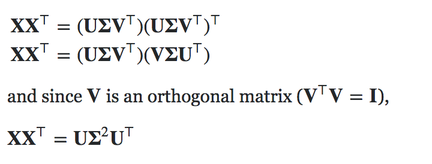

  $XX^TU = U{\sum}^2U^TU$

  $XX^TU = U{\sum}^2$
  - The columns of U are eigenvectors of $X$$\times$$X^T$
  - The columns of V are eigenvectors of $X^T$$\times$$X$
  - The non-zero elements of Σ (non-zero singular values) are the square roots of the non-zero eigenvalues of $X$$\times$$X^T$ or $X^T$$\times$$X$

## Some basic terminologies [found here](http://mathworld.wolfram.com):

- Unit Vectors: vectors of length 1, sometimes also called direction vectors $\hat{v}$ = $\frac{v}{|v|}$
- Orthogonal Vectors: Two vectors u and v whose dot product is u·v=0 are said to be orthogonal.
- Orthonormal Vectors: Unit vectors which are orthogonal are said to be orthonormal.
- Orthogonal Matrix: $U^T = U^{-1}$

  > $U^T$$\times$U = U$\times$$U^T$ = $I$

  > (Calculating $U^{-1}$ is computationally expensive O($N^3$), while calculating $U^T$ is cheap O($N^2$))
- Eigen Vector/Eigen Values: [3Blue1Brown Linear Algebra Series](http://3b1b.co/eola)

  > Av= $\lambda$v
  - A is sqaure matrix
  - v is column vector which is eigenvector
  - $\lambda$ is scalar which is eigenvalue

## R PCA functions

- princomp() - uses Eigen decomposition approach
- prcomp() - uses SVD approach

```r
# function for checking if packages have been installed and installing needed packages
installpkg <- function(x){
    if(x %in% rownames(installed.packages())==FALSE) {
        if(x %in% rownames(available.packages())==FALSE) {
            paste(x,"is not a valid package - please check again...")
        } else {
            install.packages(x)
        }

    } else {
        paste(x,"package already installed...")
    }
}

# install necessary packages
installpkg("devtools")
```

```
## [1] "devtools package already installed..."
```

```r
installpkg("factoextra")
```

```
## [1] "factoextra package already installed..."
```

### Using factoextra package to do PCA visualization

[For details, refer to this link](http://www.sthda.com/english/wiki/fviz-pca-quick-principal-component-analysis-data-visualization-r-software-and-data-mining)

```r
library(devtools)
library(factoextra)
```

```r
# ggbiplot is an implementation of the biplot using ggplot2
# the detailed information on the package can be found : https://github.com/vqv/ggbiplot
install_github("vqv/ggbiplot")
```

[output not shown]

```r
whsAnnBdatNum <- read.table("data/whs2016_AnnexB-data-wo-NAs.txt",sep="\t",header=TRUE,quote="")
summary(whsAnnBdatNum[,c(1,4,7,10,17)])
```

```
##      TOTPOP          LIFEXPB.B       MEDBIRTHS          NEWHIV
##  Min.   :      2   Min.   :50.10   Min.   :  9.00   Min.   : 0.100
##  1st Qu.:   1876   1st Qu.:66.03   1st Qu.: 78.50   1st Qu.: 0.300
##  Median :   8070   Median :72.50   Median : 96.00   Median : 1.563
##  Mean   :  37696   Mean   :71.29   Mean   : 84.28   Mean   : 1.563
##  3rd Qu.:  26413   3rd Qu.:76.38   3rd Qu.: 99.00   3rd Qu.: 1.563
##  Max.   :1383925   Max.   :83.70   Max.   :100.00   Max.   :20.100
##      ALCONS
##  Min.   : 0.000
##  1st Qu.: 2.900
##  Median : 6.085
##  Mean   : 6.085
##  3rd Qu.: 8.700
##  Max.   :17.400
```

```r
head(whsAnnBdatNum,2)
```

```
##             TOTPOP LIFEXPB.M LIFEXPB.F LIFEXPB.B HLIFEXP MATMORT MEDBIRTHS
## Afghanistan  32527      59.3      61.9      60.5    52.2     396        45
## Albania       2897      75.1      80.7      77.8    68.8      29        99
##             MORTLT5YO NEONMORT   NEWHIV TBINC  MALARIA HEPBVACC INTINTDS
## Afghanistan      91.1     35.5 0.100000   189 15.70000       75 13406517
## Albania          14.0      6.2 1.563303    19 96.96442       98       42
##             PRMORT3070 SUICIDE ALCONS MORTRAFF MODFAMPLAN ADOBIRTHS
## Afghanistan       30.5     4.0    1.0     15.5   54.70656      51.9
## Albania           18.8     6.5    6.6     15.1   12.90000      19.7
##             MORTAIR MORTWASH MORTPOIS   SMOK.M   SMOK.F DRDENS AVEI13HRCCS
## Afghanistan   112.6     34.6      7.4 34.09766 11.64922    7.7    45.00000
## Albania       171.4      0.2      1.4 51.20000  7.60000   49.9    73.18229
##             STUNT5YO WAST5YO OW5YO BETTERH2O BETTERSAN CLEANFUEL AVEPM2.5
## Afghanistan     40.9     9.5   5.4        55        32        17     64.1
## Albania         23.1     9.4  23.4        95        93        67     17.1
##             DEATHND HOMICIDE DEATHCONF
## Afghanistan     0.8      7.3      40.9
## Albania         0.0      5.0       0.1
```

### Calculate PCA

```r
#pca.whs <- prcomp(scale(whsAnnBdatNum))
pca.whs <- prcomp(whsAnnBdatNum, scale =TRUE, center = TRUE)
summary(pca.whs)
```

```
## Importance of components:
##                           PC1     PC2     PC3     PC4     PC5     PC6
## Standard deviation     3.8368 1.53237 1.49807 1.45778 1.37388 1.15080
## Proportion of Variance 0.3979 0.06346 0.06065 0.05744 0.05102 0.03579
## Cumulative Proportion  0.3979 0.46133 0.52199 0.57943 0.63044 0.66623
##                           PC7     PC8     PC9    PC10   PC11    PC12
## Standard deviation     1.1000 1.04596 0.93805 0.91732 0.8816 0.84605
## Proportion of Variance 0.0327 0.02957 0.02378 0.02274 0.0210 0.01935
## Cumulative Proportion  0.6989 0.72851 0.75229 0.77503 0.7960 0.81538
##                           PC13    PC14    PC15    PC16    PC17    PC18
## Standard deviation     0.82799 0.79830 0.75875 0.72080 0.71277 0.68677
## Proportion of Variance 0.01853 0.01722 0.01556 0.01404 0.01373 0.01275
## Cumulative Proportion  0.83391 0.85113 0.86669 0.88073 0.89447 0.90721
##                           PC19    PC20    PC21    PC22    PC23    PC24
## Standard deviation     0.63555 0.62435 0.59991 0.58685 0.53531 0.51374
## Proportion of Variance 0.01092 0.01054 0.00973 0.00931 0.00774 0.00713
## Cumulative Proportion  0.91813 0.92867 0.93839 0.94770 0.95544 0.96258
##                           PC25    PC26   PC27    PC28    PC29    PC30
## Standard deviation     0.49174 0.45499 0.4468 0.42492 0.36905 0.34870
## Proportion of Variance 0.00654 0.00559 0.0054 0.00488 0.00368 0.00329
## Cumulative Proportion  0.96911 0.97471 0.9801 0.98499 0.98867 0.99195
##                           PC31    PC32    PC33    PC34    PC35    PC36
## Standard deviation     0.33427 0.29587 0.26157 0.12390 0.10749 0.05564
## Proportion of Variance 0.00302 0.00237 0.00185 0.00041 0.00031 0.00008
## Cumulative Proportion  0.99497 0.99734 0.99919 0.99960 0.99991 1.00000
##                            PC37
## Standard deviation     0.008515
## Proportion of Variance 0.000000
## Cumulative Proportion  1.000000
```

### Use Standard deviation `prcomp()$sdev` to calculate the proportion of Variance

```r
prcomp(scale(whsAnnBdatNum))$sdev[1:5]^2/sum(prcomp(scale(whsAnnBdatNum))$sdev^2)
```

```
## [1] 0.39787072 0.06346391 0.06065473 0.05743585 0.05101508
```

### Each Eigenvalue is the amount of variation retained by each PC

```r
eig_whs <- get_eigenvalue(pca.whs)
eig_whs[1:5,]
```

```
##       eigenvalue variance.percent cumulative.variance.percent
## Dim.1  14.721217        39.787072                    39.78707
## Dim.2   2.348165         6.346391                    46.13346
## Dim.3   2.244225         6.065473                    52.19894
## Dim.4   2.125126         5.743585                    57.94252
## Dim.5   1.887558         5.101508                    63.04403
```

```r
pca.whs$sdev[1:5]^2
```

```
## [1] 14.721217  2.348165  2.244225  2.125126  1.887558
```

### Use scree plot to show the percentage of variances explained by each principal component.

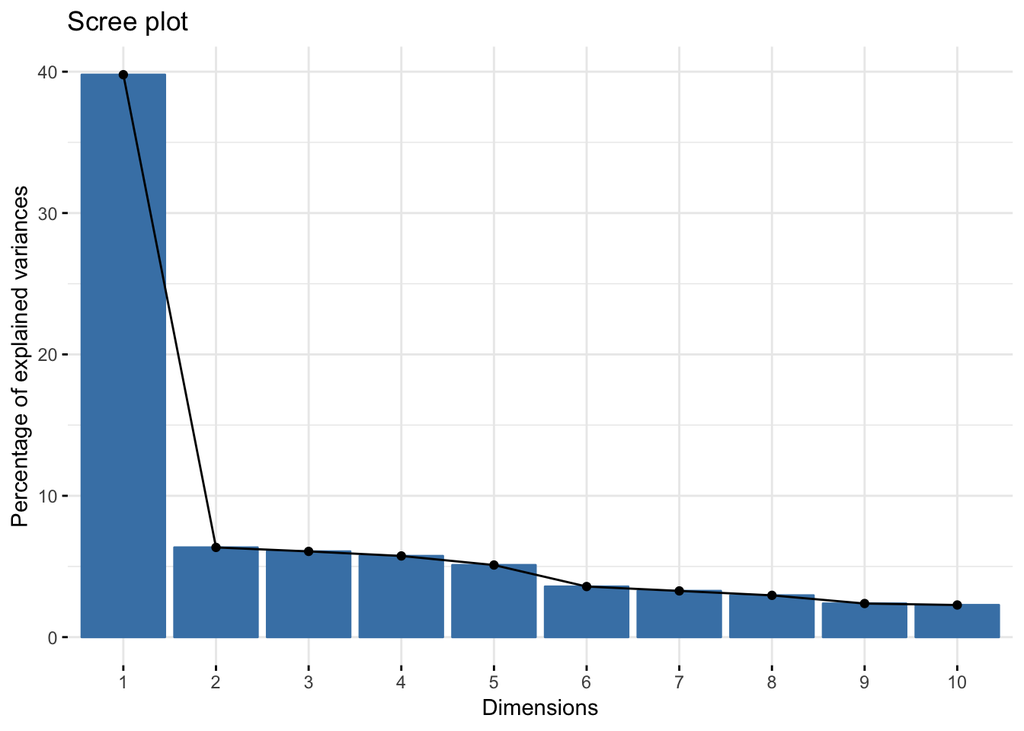

```r
#fviz_eig(pca.whs)
fviz_screeplot(pca.whs, ncp=10)
```

### Use variable loading matrix (columns are eigenvectors) `prcomp()$rotation` to show variables in PC1 dimension.

- Loadings show the correlation between a variable and a PC.
- Positive correlated variables point to the right side of the plot and negative correlated variables point to the left side.

```r
sort(abs(pca.whs$rotation[,1]),decreasing=TRUE)[1:10]
```

```
## LIFEXPB.F   HLIFEXP LIFEXPB.B MORTLT5YO LIFEXPB.M  NEONMORT   MATMORT
## 0.2530785 0.2515771 0.2505558 0.2480110 0.2436100 0.2404963 0.2325629
## BETTERSAN CLEANFUEL  MORTWASH
## 0.2309426 0.2242862 0.2229131
```

- Mortality related measures are positively correlated with the PC1 and life expectancy related measures are negatively correlated with the PC1.

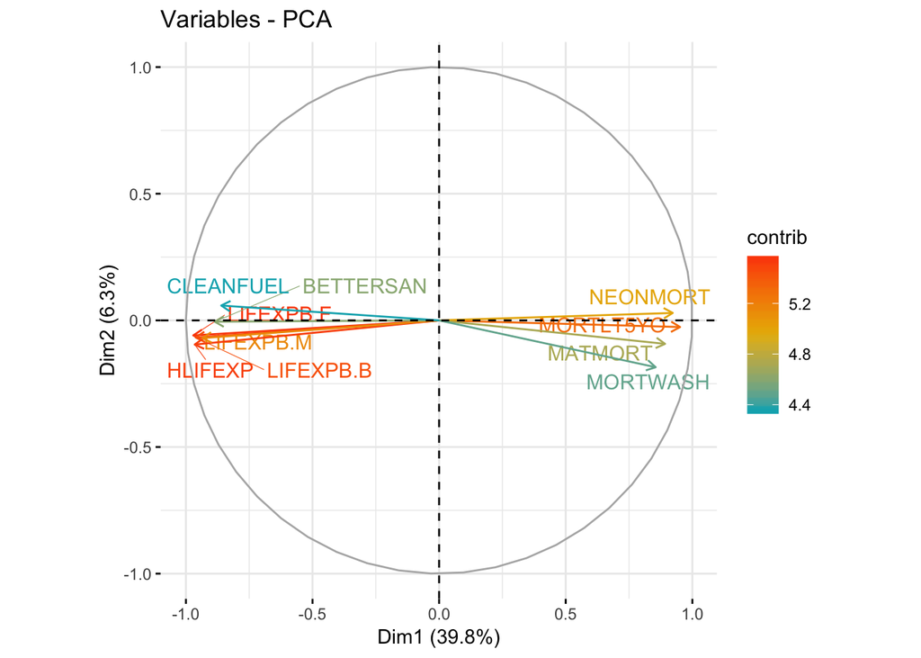

```r
fviz_pca_var(pca.whs,
             label = "var",
                axes = c(1,2 ),
                repel = TRUE,        # avoid text overlapping
                col.var = "contrib", # color vectors by their contributions to PCs
                gradient.cols = c("#00AFBB", "#E7B800", "#FC4E07"),
                select.var = list(contrib = 10)
                )
```

### Use the coordinates of the individuals (observations) on the PCs `prcomp()$x` to show individuals.

```r
(pca.whs$x)[1:5, 1:5]
```

```
##                   PC1        PC2        PC3        PC4        PC5
## Afghanistan  6.213593 -0.5154315 -1.6413083  0.8015089  1.5192032
## Albania     -2.060457 -0.9744675 -1.8931170 -1.5728821  3.1566884
## Algeria     -1.773593  1.9668454 -0.5644218  0.2131887  1.4023520
## Andorra     -1.781064 -1.8657828  0.5353795 -1.1021212  0.5520849
## Angola       9.048189 -0.5808601  0.5804153 -1.4969944 -0.3214951
```

```r
whs.ind <- get_pca_ind(pca.whs)
whs.ind$coord[1:5, 1:5]
```

```
##                 Dim.1      Dim.2      Dim.3      Dim.4      Dim.5
## Afghanistan  6.213593 -0.5154315 -1.6413083  0.8015089  1.5192032
## Albania     -2.060457 -0.9744675 -1.8931170 -1.5728821  3.1566884
## Algeria     -1.773593  1.9668454 -0.5644218  0.2131887  1.4023520
## Andorra     -1.781064 -1.8657828  0.5353795 -1.1021212  0.5520849
## Angola       9.048189 -0.5808601  0.5804153 -1.4969944 -0.3214951
```

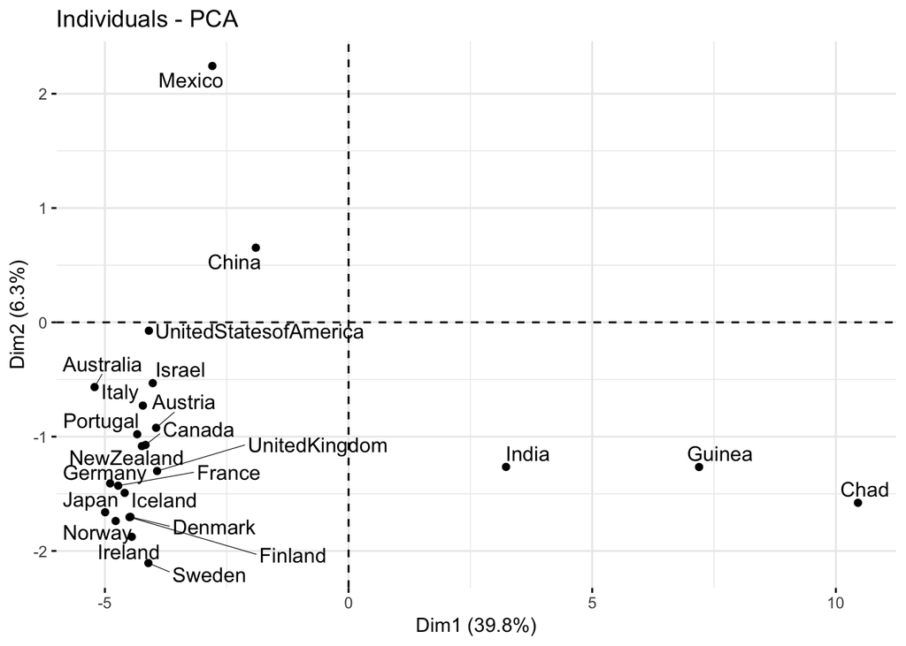

```r
tmpSelStates <- c("UnitedStatesofAmerica","UnitedKingdom","Sweden","Portugal","Norway","NewZealand","Mexico","Japan","Italy","Israel","Ireland","India","Iceland","Germany","France","Finland","Denmark","China","Canada","Australia","Austria","Guinea", "Chad")

fviz_pca_ind(pca.whs,
             label = "ind",
             select.ind = list(name = tmpSelStates),
             repel = TRUE     # Avoid text overlapping
             )
```

### Use the cosine square of the individuals (observations) on the PCs to show individuals.

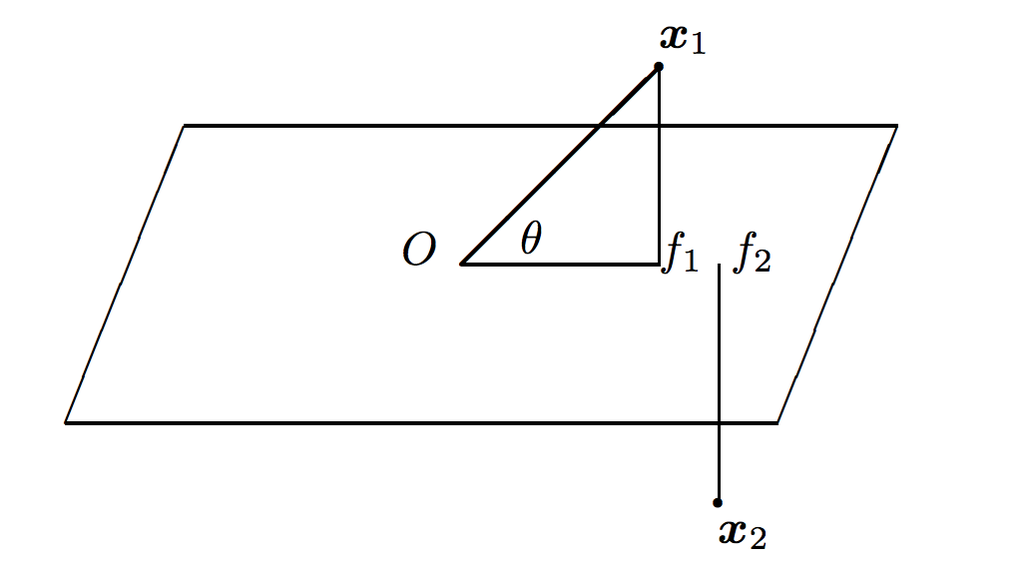

- $\theta$ is the angle between the principal plane and vector $x_i$
- cosine($\theta$) can be used as the measure of an individual representation quality. If the value is large, $x_i$ is close to the plane.

```r
whs.ind <- get_pca_ind(pca.whs)
whs.ind
```

```
## Principal Component Analysis Results for individuals
##  ===================================================
##   Name       Description
## 1 "$coord"   "Coordinates for the individuals"
## 2 "$cos2"    "Cos2 for the individuals"
## 3 "$contrib" "contributions of the individuals"
```

```r
whs.ind$cos2[1:5,1:2] # shows the importance of a component for a given individual
```

```
##                 Dim.1       Dim.2
## Afghanistan 0.6542242 0.004501766
## Albania     0.1038733 0.023233319
## Algeria     0.1987261 0.244392136
## Andorra     0.1793410 0.196807931
## Angola      0.7559680 0.003115467
```

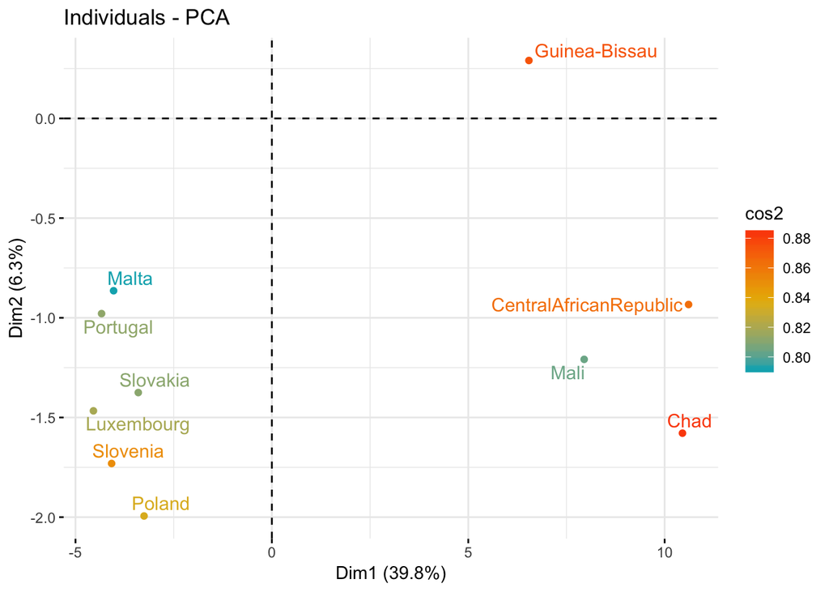

```r
fviz_pca_ind(pca.whs,
             label = "ind",
             col.ind = "cos2", # Color by the quality of representation
             gradient.cols = c("#00AFBB", "#E7B800", "#FC4E07"),
             select.ind = list(cos2 = 10), # select top # ind according to cos2
             repel = TRUE     # Avoid text overlapping
             )
```

```r
whs.contrib.top <- sort(whs.ind$contrib[,1], decreasing=TRUE)[1:10] # contribution of the individuals to the PCs
whs.contrib.top
```

```
##       CentralAfricanRepublic                         Chad
##                     3.940692                     3.826118
##                  SierraLeone                       Angola
##                     3.310338                     2.866671
##                      Somalia                   SouthSudan
##                     2.605910                     2.332363
##                         Mali DemocraticRepublicoftheCongo
##                     2.213292                     2.170259
##                      Nigeria                        Niger
##                     2.163229                     2.139650
```

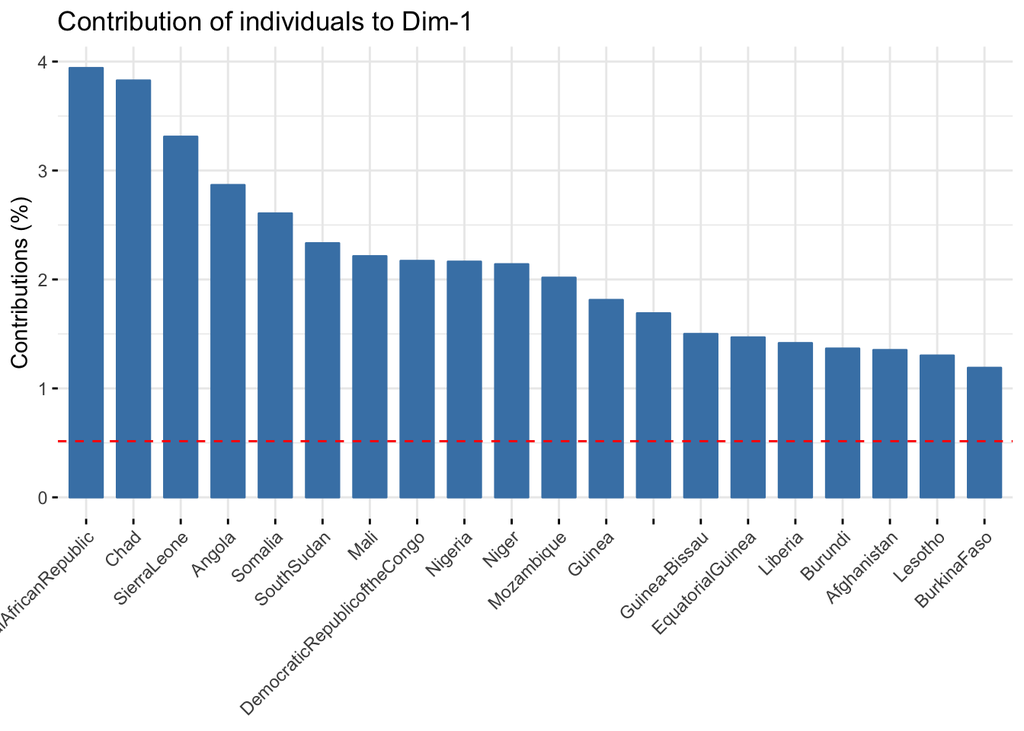

```r
# Contributions of individuals to PC1
fviz_contrib(pca.whs, choice = "ind", sort.val = "desc", axes = 1, top=20)
```

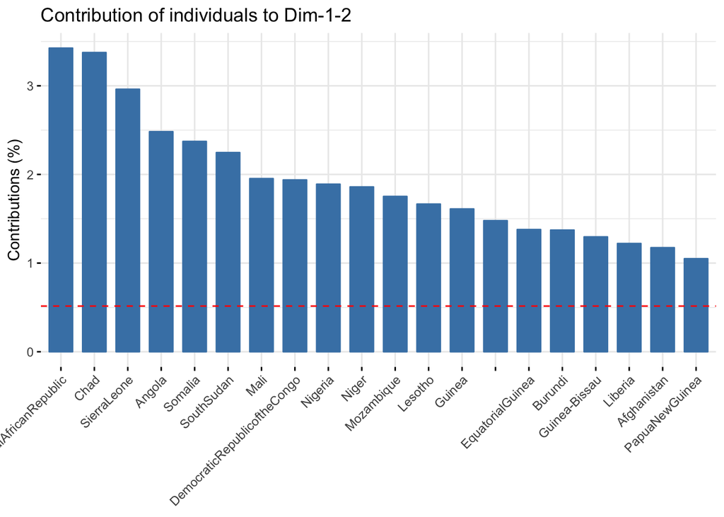

```r
# Total contribution on PC1 and PC2
fviz_contrib(pca.whs, choice = "ind", sort.val = "desc",axes = 1:2, top=20)
```

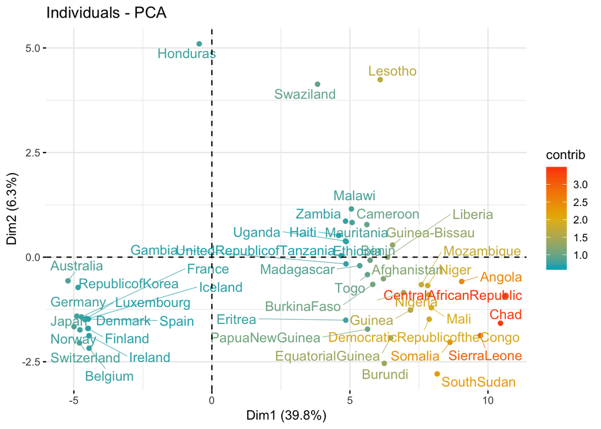

```r
fviz_pca_ind(pca.whs,
             axes =c(1:2),
             label = "ind",
             col.ind = "contrib", # Color by the quality of representation
             gradient.cols = c("#00AFBB", "#E7B800", "#FC4E07"),
             select.ind = list(contrib = 50),
             repel = TRUE     # Avoid text overlapping
             )
```

### Biplot

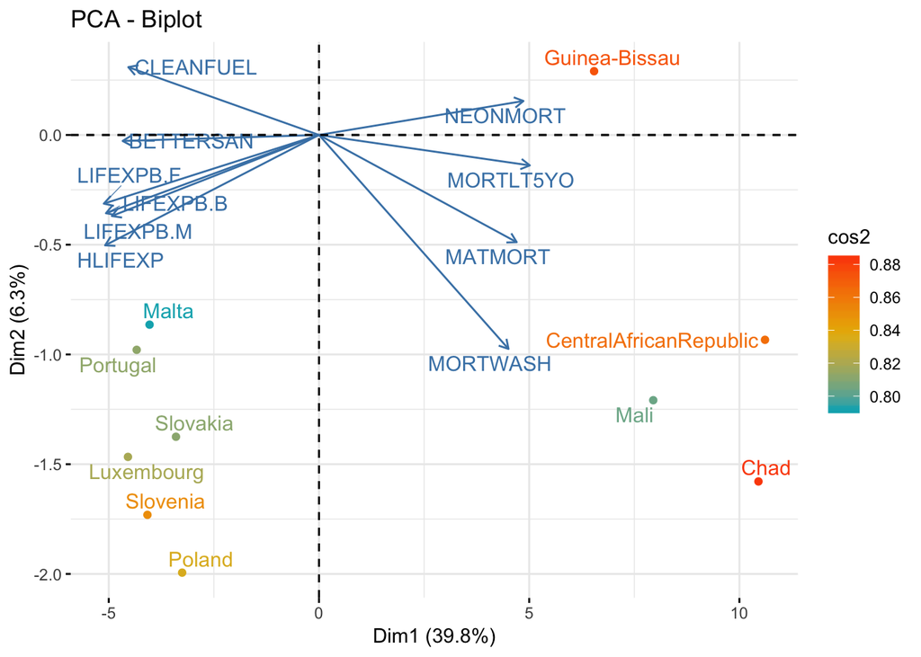

```r
fviz_pca_biplot(pca.whs,
                axes = c(1,2 ),
                repel = TRUE,        # avoid text overlapping
                label = "all",
                #col.var = "contrib", # Variables color
                gradient.cols = c("#00AFBB", "#E7B800", "#FC4E07"),
                col.ind = "cos2",  # Individuals color
                select.ind = list(cos2 = 10),
                select.var = list(contrib = 10)
                )
```